# Model 1: Ordinal regression (unstacked data)

# Ordinal regression: Explaining Tone

Here we just model a simple Ordinal regression -i.e., the data is not stacked- and the focus is on the Dominant frame and Tone. Mixed effects models are covered elsewhere.

## Model 1

Let’s start with something like a favoured model, before inspecting others. Dependent variable is Tone, predictors are wordN, year, sourceForamt, visibility, country and level.

The regression output can be difficult deal with (see Annex model 1). There are more than 20 coefficients, as well 2 intercepts. Coefficients with large t-values are indicative of important predictors, but with so many interactions it’s hard to tell what’s happening. To evaluate whether the interactions are significant as well as other factor variables, we can use the Anova function from R’s car package to check predictors and interactions.

### Check predictors

The Anova result shows that the Country * Level interaction is significant as well as other variables except for sourceFormat and year. We can’t interpret the interaction coefficients, we need to graph them to understand what’s going on.

```
## Analysis of Deviance Table (Type II tests)
##
## Response: domTone2
##               LR Chisq Df Pr(>Chisq)
## wordN           20.026  1  7.639e-06 ***
## year2            0.288  1  0.5912171
## sourceFormat     1.972  1  0.1602278
## vis             22.569  4  0.0001544 ***
## country         57.584  7  4.576e-10 ***
## level           19.070  1  1.260e-05 ***
## country:level   22.964  7  0.0017293 **
## ---
## Signif. codes:  0 '***' 0.001 '**' 0.01 '*' 0.05 '.' 0.1 ' ' 1
```

### Visualise interactions

Since interactions terms are not directly interpretable, even in a simple model, visualisation is the only way to understand what is going on. To see the effect of the interactions we can calculate predicted values for a change in the territorial level while holding all other predictors at fixed values. Plotting the predicted values for these interactions allows us to see how the probabilities change from one level to the other.

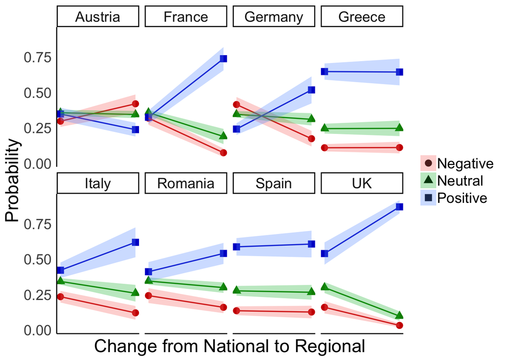

Now we can see how the model really works for the interaction. For example, for the UK we can clearly see that the probability of being classified as “Positive” increases dramatically when moving from National to Regional. At the same time the probability of being “Neutral” or “Negative” is also reduced. A similar dynamic occurs in France and in Italy. In Germany and Romania there is also some change obvious change in the probability of being “Positve”. On the other hand, in Greece and Spain there doesn’t seem to be much change, while Austria seems to buck the trend.

## Model 2: Adding more story information (Economics vs Politics) in the regression

The Frame variable (called dim) is obviously the key variable explaining Tone. My worry is that it is virtually true by defintion. That’s why we get such huge coefficients. The complicated regression is in Annex model 2. For now we can look at core variables.

### Check the key predictors

```
## Analysis of Deviance Table (Type II tests)
##
## Response: domTone2
##              LR Chisq Df Pr(>Chisq)
## sourceFormat    0.003  1  0.9541800
## wordN          11.807  1  0.0005901 ***
## year2           0.102  1  0.7498734
## vis            14.929  4  0.0048498 **
## dim           272.974  1  < 2.2e-16 ***
## country        38.469  7  2.467e-06 ***
## level           1.661  1  0.1975199
## ---
## Signif. codes:  0 '***' 0.001 '**' 0.01 '*' 0.05 '.' 0.1 ' ' 1
```

Here we can see how dim (the Economics vs Politics) drives everything. We can also see that it is the Frames (called dim) that drives it all. Country is the other signficant predictor. Level drops out. This basically tells us that these are the two core variables.

### Checking a country attribute

As an aside, we can see what using a crossed country attribute such as NetPayer does.

### Check the key predictors with NetPayer

Here you can see it all drops out. We will come back to this with mixed effects.

```
## Analysis of Deviance Table (Type II tests)
##
## Response: domTone2
##              LR Chisq Df Pr(>Chisq)
## sourceFormat    0.057  1   0.810911
## wordN           9.148  1   0.002490 **
## year2           0.851  1   0.356334
## vis            13.815  4   0.007909 **
## dim           281.600  1  < 2.2e-16 ***
## NetPayer        0.015  1   0.901148
## level           3.379  1   0.066024 .
## ---
## Signif. codes:  0 '***' 0.001 '**' 0.01 '*' 0.05 '.' 0.1 ' ' 1
```

## Model 3: Adding interactions

We can add some interactions that would improve the model. The basic message here is that most stuff you start interacting with Frames is going to be signficant. As is the case with country and level in the model below.

Here we’ve added a complicated three-way interaction (dim X country X level). To see how comlicated it is go to Annex model 3.

```
## Analysis of Deviance Table (Type II tests)
##
## Response: domTone2
##                   LR Chisq Df Pr(>Chisq)
## sourceFormat         0.163  1  0.6863608
## wordN               11.862  1  0.0005728 ***
## year2                0.059  1  0.8085134
## vis                 10.714  4  0.0299761 *
## dim                262.952  1  < 2.2e-16 ***
## country             38.538  7  2.394e-06 ***
## level                3.193  1  0.0739630 .
## country:level       18.905  7  0.0084895 **
## dim:country         39.743  7  1.410e-06 ***
## dim:level           10.324  1  0.0013130 **
## dim:country:level   12.203  7  0.0940724 .
## ---
## Signif. codes:  0 '***' 0.001 '**' 0.01 '*' 0.05 '.' 0.1 ' ' 1
```

## Model 4

The three way interaction is not necessary -it’s not significant at the 0.05 level. So, let’s just proceed with the 2 way interaction for frames of model 4 and consider this the best model.

```
## Analysis of Deviance Table (Type II tests)
##
## Response: domTone2
##              LR Chisq Df Pr(>Chisq)
## sourceFormat    0.214  1   0.643788
## wordN           9.849  1   0.001699 **
## year2           0.285  1   0.593342
## vis            13.296  4   0.009918 **
## dim           272.974  1  < 2.2e-16 ***
## country        38.538  7  2.394e-06 ***
## level           3.193  1   0.073963 .
## dim:country    36.061  7  7.059e-06 ***
## dim:level       9.539  1   0.002011 **
## ---
## Signif. codes:  0 '***' 0.001 '**' 0.01 '*' 0.05 '.' 0.1 ' ' 1
```

### Visualising the interaction model (with Dominant Frame)

Having established our best model, let’s see what’s happening with the interactions. You can’t really tell from the coefficients. Here’s the plot showing where most of the action is: the Frame * Country interaction.

The graph tells the story that will probably apply across the modeling efforts when frames are included. Big changes from in the Negative Tone when moving Economics to Politics frames on the one hand, and for the Postive Tone, when making the same move, but in reverse. These patterns are similar across the countries -albeit with different slopes. Much less happening in the nuetral category.

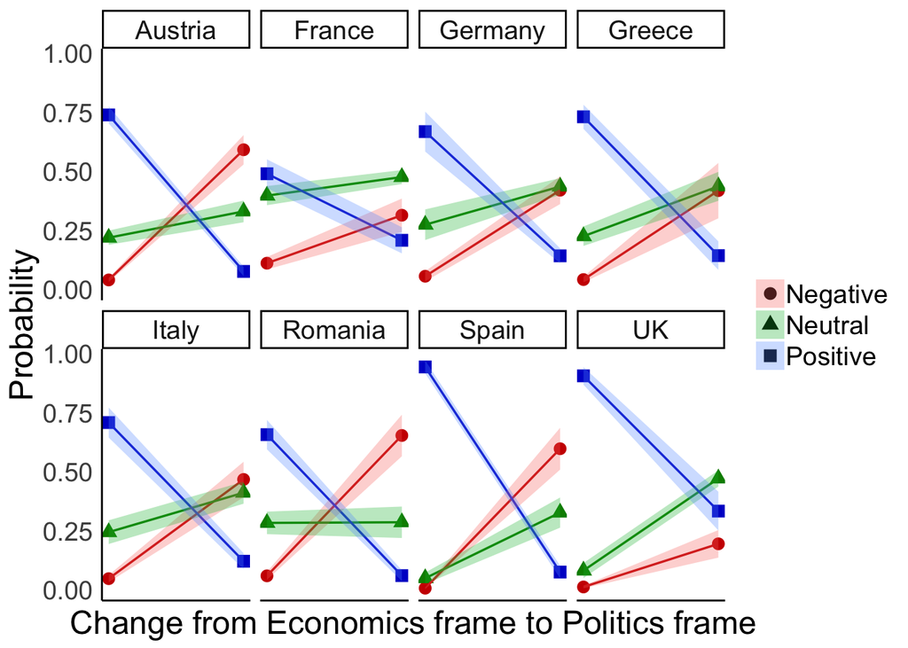

### Visualise interaction Frames * Level

Here we will look at the Frames X Level interaction. This interaction has less explanatory power than the Frames X Country interaction above. Even though this interaction appears as significant in the output, you can’t see much change between territorial level (the error plots are on the same horizontal level). The only signficannt change is the shift from the from Economics frame to the Politics frame.

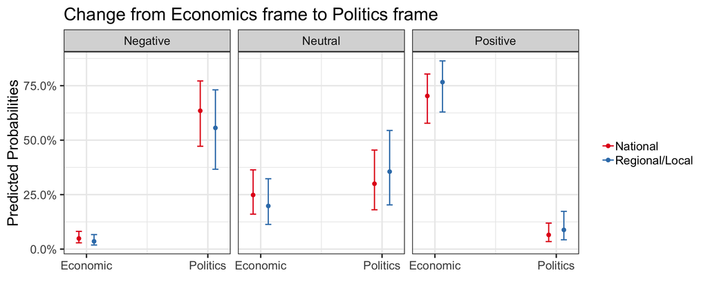

# Summary

The basic message is that Frames drives everything in relation to the Tone, and Country is the next most important variable.

# Annex model 1

```
## Call:
## polr(formula = domTone2 ~ wordN + year2 + sourceFormat + vis +
##     country * (level), data = df, Hess = T)
##
## Coefficients:
##                                        Value Std. Error t value
## wordN                              -0.001121  0.0002611 -4.2921
## year2                              -0.054508  0.1012300 -0.5385
## sourceFormatOnline only             0.232640  0.1650533  1.4095
## vis.L                              -0.444350  0.1993190 -2.2293
## vis.Q                               0.454196  0.1823184  2.4912
## vis.C                              -0.089206  0.1988951 -0.4485
## vis^4                              -0.204078  0.1864424 -1.0946
## countryFrance                      -0.103420  0.2764317 -0.3741
## countryGermany                     -0.516462  0.2776423 -1.8602
## countryGreece                       1.234893  0.3058874  4.0371
## countryItaly                        0.315489  0.2804970  1.1247
## countryRomania                      0.272598  0.3259957  0.8362
## countrySpain                        0.982239  0.3068487  3.2011
## countryUK                           0.789551  0.3539753  2.2305
## levelRegional/Local                -0.538159  0.1636127 -3.2892
## countryFrance:levelRegional/Local   2.304240  0.4493839  5.1276
## countryGermany:levelRegional/Local  1.753791  0.4110545  4.2666
## countryGreece:levelRegional/Local   0.524045  0.4481814  1.1693
## countryItaly:levelRegional/Local    1.338075  0.4651205  2.8768
## countryRomania:levelRegional/Local  1.058110  0.3866296  2.7368
## countrySpain:levelRegional/Local    0.619831  0.4381694  1.4146
## countryUK:levelRegional/Local       2.272156  0.4758062  4.7754
##
## Intercepts:
##                  Value   Std. Error t value
## Negative|Neutral -1.2837  0.3258    -3.9398
## Neutral|Positive  0.2111  0.3246     0.6501
##
## Residual Deviance: 1462.218
## AIC: 1510.218
## (14 observations deleted due to missingness)
```

# Annex model 2

```
## Call:
## polr(formula = domTone2 ~ sourceFormat + wordN + year2 + vis +
##     dim + country + level, data = df, Hess = TRUE)
##
## Coefficients:
##                              Value Std. Error   t value
## sourceFormatOnline only  0.0101792  0.1772921   0.05741
## wordN                   -0.0009314  0.0002799  -3.32702
## year2                   -0.0347270  0.1089390  -0.31878
## vis.L                    0.3377184  0.2148063   1.57220
## vis.Q                    0.4901749  0.1942679   2.52319
## vis.C                    0.0312050  0.2130959   0.14644
## vis^4                   -0.5050578  0.1981878  -2.54838
## dimPolitics             -2.9123895  0.1956875 -14.88286
## countryFrance           -0.1267797  0.3012950  -0.42078
## countryGermany           0.3160263  0.2957065   1.06872
## countryGreece            0.4013024  0.3223153   1.24506
## countryItaly             0.2830588  0.3044791   0.92965
## countryRomania          -0.1009130  0.3122651  -0.32316
## countrySpain             0.7926131  0.3174926   2.49648
## countryUK                1.5998898  0.3559811   4.49431
## levelRegional/Local      0.2288974  0.1779934   1.28599
##
## Intercepts:
##                  Value    Std. Error t value
## Negative|Neutral  -3.2475   0.4075    -7.9688
## Neutral|Positive  -1.1986   0.3874    -3.0939
##
## Residual Deviance: 1212.208
## AIC: 1248.208
## (14 observations deleted due to missingness)
```

# Annex model 3

```
## Call:
## polr(formula = domTone2 ~ sourceFormat + wordN + year2 + vis +
##     dim * (country * level), data = df, Hess = TRUE)
##
## Coefficients:
##                                                     Value Std. Error
## sourceFormatOnline only                         7.495e-02  1.843e-01
## wordN                                          -9.779e-04  2.890e-04
## year2                                          -2.776e-02  1.138e-01
## vis.L                                           4.162e-01  2.254e-01
## vis.Q                                           3.819e-01  2.039e-01
## vis.C                                          -1.267e-02  2.237e-01
## vis^4                                          -4.605e-01  2.085e-01
## dimPolitics                                    -3.275e+00  2.264e-01
## countryFrance                                  -1.576e+00  3.072e-01
## countryGermany                                 -6.514e-01  3.877e-01
## countryGreece                                   5.265e-02  3.300e-01
## countryItaly                                   -1.883e-01  3.413e-01
## countryRomania                                 -1.190e-01  3.808e-01
## countrySpain                                    1.459e+00  4.962e-01
## countryUK                                       9.252e-01  4.172e-01
## levelRegional/Local                             5.077e-01  2.462e-01
## countryFrance:levelRegional/Local               1.561e+00  4.269e-01
## countryGermany:levelRegional/Local              6.592e-01  3.556e-01
## countryGreece:levelRegional/Local              -3.619e-01  5.327e-01
## countryItaly:levelRegional/Local                1.514e-01  4.411e-01
## countryRomania:levelRegional/Local             -5.594e-01  4.291e-01
## countrySpain:levelRegional/Local                1.360e+01  5.026e-01
## countryUK:levelRegional/Local                   4.223e-01  4.041e-01
## dimPolitics:countryFrance                       2.485e+00  4.004e-01
## dimPolitics:countryGermany                      1.131e+00  3.950e-01
## dimPolitics:countryGreece                       9.639e-01  5.749e-01
## dimPolitics:countryItaly                        4.692e-01  4.075e-01
## dimPolitics:countryRomania                     -1.068e-01  4.668e-01
## dimPolitics:countrySpain                       -1.133e+00  6.010e-01
## dimPolitics:countryUK                           1.235e-01  4.412e-01
## dimPolitics:levelRegional/Local                -9.391e-01  3.852e-01
## dimPolitics:countryFrance:levelRegional/Local  -9.282e-01  2.935e-01
## dimPolitics:countryGermany:levelRegional/Local -2.642e-01  3.164e-01
## dimPolitics:countryGreece:levelRegional/Local  -1.373e+01  2.202e-06
```

[output cut: 37 more lines]

```
## dimPolitics:countryGermany:levelRegional/Local -8.349e-01
## dimPolitics:countryGreece:levelRegional/Local  -6.236e+06
## dimPolitics:countryItaly:levelRegional/Local    1.117e+00
## dimPolitics:countryRomania:levelRegional/Local -1.031e+00
## dimPolitics:countrySpain:levelRegional/Local   -3.073e+01
## dimPolitics:countryUK:levelRegional/Local       4.949e+00
##
## Intercepts:
##                  Value         Std. Error    t value
## Negative|Neutral       -3.6863        0.3687       -9.9990
## Neutral|Positive       -1.4908        0.3506       -4.2526
##
## Residual Deviance: 1133.925
## AIC: 1213.925
## (14 observations deleted due to missingness)
```

# Annex model 4

```
## Call:
## polr(formula = domTone2 ~ sourceFormat + wordN + year2 + vis +
##     dim * (country + level), data = df, Hess = TRUE)
##
## Coefficients:
##                                      Value Std. Error  t value
## sourceFormatOnline only          0.0842843  0.1818904   0.4634
## wordN                           -0.0008722  0.0002865  -3.0439
## year2                           -0.0597086  0.1115440  -0.5353
## vis.L                            0.5102394  0.2172543   2.3486
## vis.Q                            0.4008136  0.1985901   2.0183
## vis.C                           -0.0422447  0.2174429  -0.1943
## vis^4                           -0.4696052  0.2037013  -2.3054
## dimPolitics                     -3.1970718  0.2293821 -13.9378
## countryFrance                   -1.1418995  0.2883220  -3.9605
## countryGermany                  -0.4443857  0.3953618  -1.1240
## countryGreece                   -0.0633760  0.3068043  -0.2066
## countryItaly                    -0.1672590  0.3376758  -0.4953
## countryRomania                  -0.5687689  0.3199766  -1.7775
## countrySpain                     1.7608674  0.4927536   3.5735
## countryUK                        1.0269407  0.4367294   2.3514
## levelRegional/Local              0.8317015  0.2516258   3.3053
## dimPolitics:countryFrance        2.1346450  0.4071971   5.2423
## dimPolitics:countryGermany       1.0070275  0.4335092   2.3230
## dimPolitics:countryGreece        0.6045266  0.5226456   1.1567
## dimPolitics:countryItaly         0.5018955  0.4241976   1.1832
## dimPolitics:countryRomania       0.1891194  0.4665085   0.4054
## dimPolitics:countrySpain        -1.8339389  0.5798317  -3.1629
## dimPolitics:countryUK            0.7392452  0.5366680   1.3775
## dimPolitics:levelRegional/Local -1.1480639  0.3766912  -3.0478
##
## Intercepts:
##                  Value    Std. Error t value
## Negative|Neutral  -3.5999   0.3746    -9.6110
## Neutral|Positive  -1.4746   0.3558    -4.1442
##
## Residual Deviance: 1165.033
## AIC: 1217.033
## (14 observations deleted due to missingness)
```